# Reproducible Research: Peer Assessment 1

## Loading and preprocessing the data

```r
activity_df <- read.csv(unz("activity.zip","activity.csv"))
activity_df$date <- as.Date(activity_df$date)
activity_df$weekday <- weekdays(activity_df$date)
```

## What is mean total number of steps taken per day?

```r
library(dplyr)
```

```
## stat_bin: binwidth defaulted to range/30. Use 'binwidth = x' to adjust this.
```

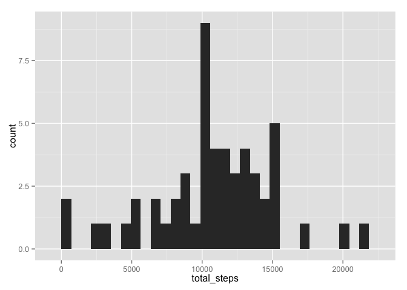

```r
library(ggplot2)

daily_totals <- activity_df %>%
                  group_by(date) %>%
                  summarise(total_steps = sum(steps))

ggplot(daily_totals, aes(x = total_steps)) +
      geom_histogram()
```

```r
mean_steps <- mean(daily_totals$total_steps, na.rm = TRUE)
median_steps <- median(daily_totals$total_steps, na.rm = TRUE)
```

The **mean** number of steps per day is: 1.0766 × 10<sup>4</sup>

The **median** number of steps per day is: 10765

## What is the average daily activity pattern?

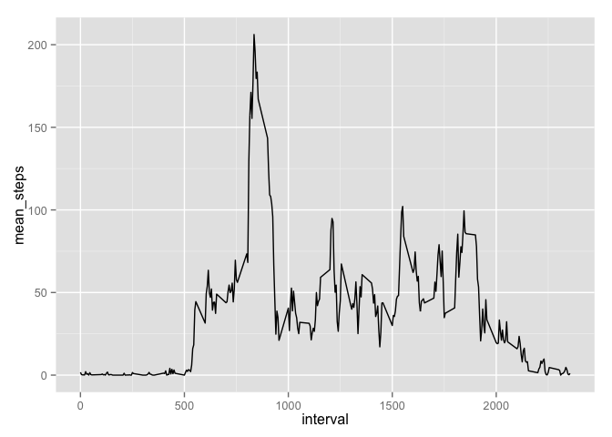

```r
interval_mean <- activity_df %>%
                  group_by(interval) %>%
                  summarise(mean_steps = mean(steps, na.rm = TRUE))
ggplot(interval_mean, aes(x = interval, y = mean_steps)) +
      geom_line()
```

```r
max_interval <- interval_mean$interval[which.max(interval_mean$mean_steps)]
max_steps <- max(interval_mean$mean_steps)
```

On average the 835 interval contains the **max** steps of 206.1698 steps.

## Imputing missing values

```r
summary(activity_df)
```

```
##      steps            date               interval      weekday
##  Min.   :  0.0   Min.   :2012-10-01   Min.   :   0   Length:17568
##  1st Qu.:  0.0   1st Qu.:2012-10-16   1st Qu.: 589   Class :character
##  Median :  0.0   Median :2012-10-31   Median :1178   Mode  :character
##  Mean   : 37.4   Mean   :2012-10-31   Mean   :1178
##  3rd Qu.: 12.0   3rd Qu.:2012-11-15   3rd Qu.:1766
##  Max.   :806.0   Max.   :2012-11-30   Max.   :2355
##  NA's   :2304
```

```r
num_nas <- sum(is.na(activity_df$steps))
```

There are a total of 2304 NA’s in the dataset.

Use the average number of steps from each time interval from the same weekday to fill in NA’s

```r
na_inicies <- which(is.na(activity_df$steps))
na_steps_df <- activity_df[na_inicies,]

weekday_interval_df <- activity_df %>%
                  group_by(weekday, interval) %>%
                  summarise(mean_steps = mean(steps, na.rm = TRUE))

impute_vals <- left_join(x = na_steps_df,
                         y = weekday_interval_df,
                         by = c("weekday", "interval"))

steps_no_na <- activity_df$steps
steps_no_na[na_inicies] <- impute_vals$mean_steps
activity_df_clean <- activity_df
activity_df_clean$steps <- steps_no_na

summary(activity_df_clean)
```

```
##      steps            date               interval      weekday
##  Min.   :  0.0   Min.   :2012-10-01   Min.   :   0   Length:17568
##  1st Qu.:  0.0   1st Qu.:2012-10-16   1st Qu.: 589   Class :character
##  Median :  0.0   Median :2012-10-31   Median :1178   Mode  :character
##  Mean   : 37.6   Mean   :2012-10-31   Mean   :1178
##  3rd Qu.: 19.0   3rd Qu.:2012-11-15   3rd Qu.:1766
##  Max.   :806.0   Max.   :2012-11-30   Max.   :2355
```

```
## stat_bin: binwidth defaulted to range/30. Use 'binwidth = x' to adjust this.
```

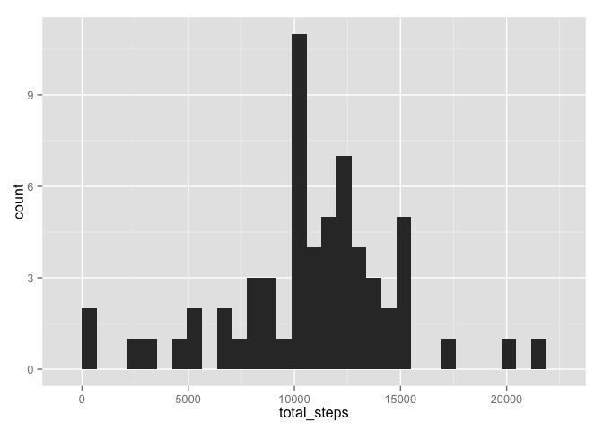

```r
daily_totals_clean <- activity_df_clean %>%
                          group_by(date) %>%
                          summarise(total_steps = sum(steps))

ggplot(daily_totals_clean, aes(x = total_steps)) +
      geom_histogram()
```

```r
mean_steps_clean <- mean(daily_totals_clean$total_steps)
median_steps_clean <- median(daily_totals_clean$total_steps)
```

The **new mean** number of steps per day is: 1.0821 × 10<sup>4</sup>

The **new median** number of steps per day is: 1.1015 × 10<sup>4</sup>

The mean number of steps per day ignoring NA’s was **1.0766 × 10<sup>4</sup>** while the mean number of steps after filling in the NA’s is **1.0821 × 10<sup>4</sup>**

This could mean that when ignoring the NA values we are possibly biasing our results. Therefore we should be smart about the way in which we handle missing data. For this example I felt it was appropriate to fill in the missing steps with the average from the same interval and same day of the week. I did not think that it would be fair to average all values from the same interval since, as we will see in the next section, there could be different activity patterens depending on the day of week.

## Are there differences in activity patterns between weekdays and weekends?

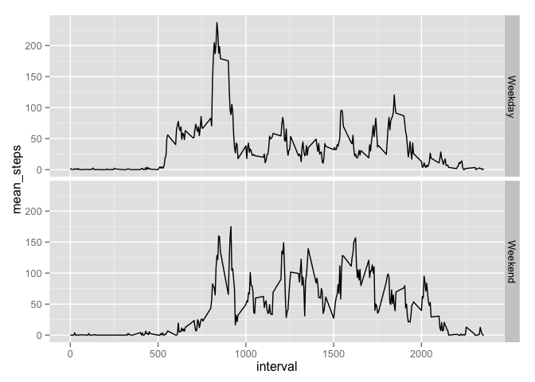

```r
activity_df_clean$day_category <- ifelse(activity_df_clean$weekday %in% c("Saturday","Sunday"),"Weekend", "Weekday")

weekday_interval <- activity_df_clean %>%
                        group_by(interval, day_category) %>%
                        summarise(mean_steps = mean(steps))

ggplot(weekday_interval, aes(x = interval, y = mean_steps)) +
      geom_line() +
      facet_grid(day_category~.)
```

```r
compare <- weekday_interval %>%
                  group_by(day_category) %>%
                  summarise(mean_steps = mean(mean_steps))
mean_weekday <- compare$mean_steps[compare$day_category=="Weekday"]
mean_weekend <- compare$mean_steps[compare$day_category=="Weekend"]
print(compare)
```

```
## Source: local data frame [2 x 2]
##
##   day_category mean_steps
## 1      Weekday      35.62
## 2      Weekend      43.08
```

Examing the plots above show that for this person most of their activity happends early morning on weekdays, then drops down for pretty much the rest of the day. While on weekends, the activity seems to start a bit later (perhaps they enjoy sleeping in :) ) but the activity throughout the day is on average at a higher level. Infact, the average steps per 5 min interval on the weekdays is 35.6164 steps vs. 43.0784 steps on the weekend.